# Modelos Tobit

Regresión con variable dependiente censurada

Diego Müller · MCI002 — Universidad de La Frontera

2026-06-01

## Repositorio: código, datos y estas slides

Todo el material (presentación, código R y bases de datos) está en el repositorio. **Escanea el QR** para seguirlo o replicarlo.

**Tesis de hoy:** un *mismo* método (Tobit) sobre *dos* realidades. Veremos cuándo luce impecable y cuándo la realidad lo pone a prueba.

[figure not shown]

## Hoja de ruta

1. **El problema**: ¿qué resuelve Tobit?
2. **Fundamentos** matemáticos
3. **Metodología**: estimación y métricas
4. **Práctico A** — lluvia (ingeniería)
5. **Práctico B** — aptitud (modelo “de manual”)
6. **Comparación** y análisis crítico
7. Ventajas, límites y conclusiones

# 1 · El problema

## Variables “limitadas” o censuradas

Muchas variables de ingeniería **se acumulan en un límite**:

- **Lluvia diaria**: 0 mm en días secos.
- **Concentración de un contaminante**: por debajo del *límite de detección* del instrumento.
- **Sensor saturado**: marca su tope máximo.
- **Demanda / consumo**: muchos ceros.

**Censura:** observamos *todas* las unidades, pero la variable está **recortada** en un umbral. El valor “real” existe, no lo medimos bien.

> El censurado **no** es lo mismo que un dato faltante ni que truncamiento (ahí *perdemos* observaciones).

## ¿Por qué no usar una regresión lineal (OLS)?

Si ignoramos la censura y corremos OLS:

- Los coeficientes quedan **sesgados** (la nube de ceros “tira” la recta).
- Puede predecir **valores imposibles** (lluvia negativa, puntajes sobre el techo).

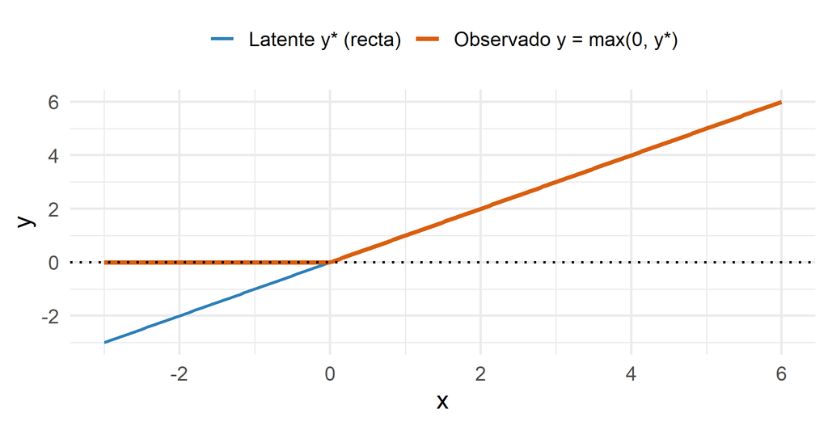

# 2 · Fundamentos matemáticos

## La idea central: una variable **latente**

Postulamos una variable **no observada** $y^*$ lineal en las covariables:

$$y_i^{*} = \mathbf{x}_i^{\top}\boldsymbol{\beta} + \varepsilon_i, \qquad \varepsilon_i \sim \mathcal{N}(0,\sigma^2)$$

Pero solo observamos una versión **recortada** en el umbral de censura:

**Censura por la izquierda** (en 0):
$$y_i = \max(0,\; y_i^{*})$$
*(ej.: lluvia)*

**Censura por la derecha** (en $U$):
$$y_i = \min(y_i^{*},\; U)$$
*(ej.: aptitud, techo 800)*

## La verosimilitud combina **dos piezas**

Para las observaciones **no censuradas**: aportan su **densidad** (como en OLS). Para las **censuradas**: solo sabemos que $y^*$ cayó tras el umbral → aportan una **probabilidad**.

$$\mathcal{L}(\boldsymbol\beta,\sigma)=
\underbrace{\prod_{y_i>0}\tfrac{1}{\sigma}\,\phi\!\Big(\tfrac{y_i-\mathbf{x}_i^\top\boldsymbol\beta}{\sigma}\Big)}_{\text{no censuradas: densidad}}
\;\times\;
\underbrace{\prod_{y_i=0}\Phi\!\Big(\tfrac{-\mathbf{x}_i^\top\boldsymbol\beta}{\sigma}\Big)}_{\text{censuradas: probabilidad}}$$

$\phi$ = densidad normal, $\Phi$ = acumulada normal. Se maximiza $\log\mathcal{L}$ → estimador de **máxima verosimilitud (MLE)**.

## Supuestos e interpretación de parámetros

**Supuestos (fuertes):**

- $\varepsilon$ **normal**.
- $\varepsilon$ **homocedástico** (varianza constante).
- Linealidad y exogeneidad de $\mathbf{x}$.

**Parámetros:**

- $\beta_j$ = efecto sobre la **latente** $y^*$.
- $\sigma$ = escala del error latente.

⚠️ **Clave:** a diferencia de OLS, si en Tobit fallan la normalidad o la homocedasticidad, el MLE es **sesgado e inconsistente** (no solo ineficiente). Por eso *hay que testear los supuestos*.

## El coeficiente **no** es el efecto observado: efectos marginales

$\beta_j$ mide el efecto sobre $y^*$. El efecto sobre lo que **observamos** es menor (se “encoge” por la probabilidad de estar censurado):

$$\frac{\partial\, E[y_i\mid \mathbf{x}_i]}{\partial x_{ij}} = \beta_j \cdot \Phi\!\Big(\tfrac{\mathbf{x}_i^\top\boldsymbol\beta}{\sigma}\Big) \;\;(\text{censura izq. en 0})$$

- El factor $\Phi(\cdot)\in(0,1)$ es la **probabilidad de no estar censurado**.
- Por eso siempre reportamos **efectos marginales**, no solo los $\beta$.
- Aparece la **razón inversa de Mills** $\lambda=\phi/\Phi$ al derivar.

# 3 · Metodología: estimación y evaluación

## ¿Cómo se ajusta y cómo se mide?

**Estimación**

- **Máxima verosimilitud** (Newton-Raphson).
- Datos: $y$ continua con **umbral de censura conocido** + covariables.
- En R: `censReg`, `AER::tobit`, `crch`, `VGAM`.

**Capacidad predictiva / ajuste**

- **Pseudo-R² McKelvey–Zavoina** *(principal: escala latente)*.
- McFadden (verosimilitud) y **cor²** (escala observada).
- **AIC** y **test de razón de verosimilitud**.

$$R^2_{\text{MZ}}=\frac{\widehat{\operatorname{Var}}(\hat y^{*})}{\widehat{\operatorname{Var}}(\hat y^{*})+\sigma^{2}}\qquad
R^2_{\text{McF}}=1-\frac{\ell(\hat{\boldsymbol\beta})}{\ell_{0}}$$

## Diagnóstico de supuestos

Como los supuestos son críticos, los testeamos formalmente:

1. **Residuos generalizados** (Chesher–Irish): residuo estándar si la obs. no está censurada; valor esperado del error truncado si lo está.
2. **Normalidad**: asimetría/curtosis + **Jarque-Bera** + QQ-plot; comparar AIC con error t-Student.
3. **Homocedasticidad**: **test LR** entre Tobit homocedástico vs **heterocedástico** (`crch`, con $\log\sigma$ función de las covariables).

Si se violan → remedios: **errores robustos**, **Tobit heterocedástico**, transformar $y$, o modelos de **selección (Heckman)**.

# 4A · Práctico A - Lluvia en Sydney

## Los datos (ingeniería / recursos hídricos)

```r
# Carga directa desde GitHub (link raw):
url <- "https://raw.githubusercontent.com/1mulerd/workshop4-tobit-mci002/main/data/lluvia_tobit.csv"
lluvia <- read.csv(url)
```

```r
f_ll <- lluvia_mm ~ temp_max + viento_max + humedad_pm + presion_pm + nubosidad_pm
c(observaciones = nrow(lluvia), dias_secos = sum(lluvia$lluvia_mm == 0))
```

```
observaciones    dias_secos
         2948          1895
```

**Fuente:** *Rain in Australia* (Australian Bureau of Meteorology). DV `lluvia_mm` (mm), censurada en **0**. Predictores: temperatura máx., ráfaga de viento, humedad, presión y nubosidad (15 h).

## La censura salta a la vista

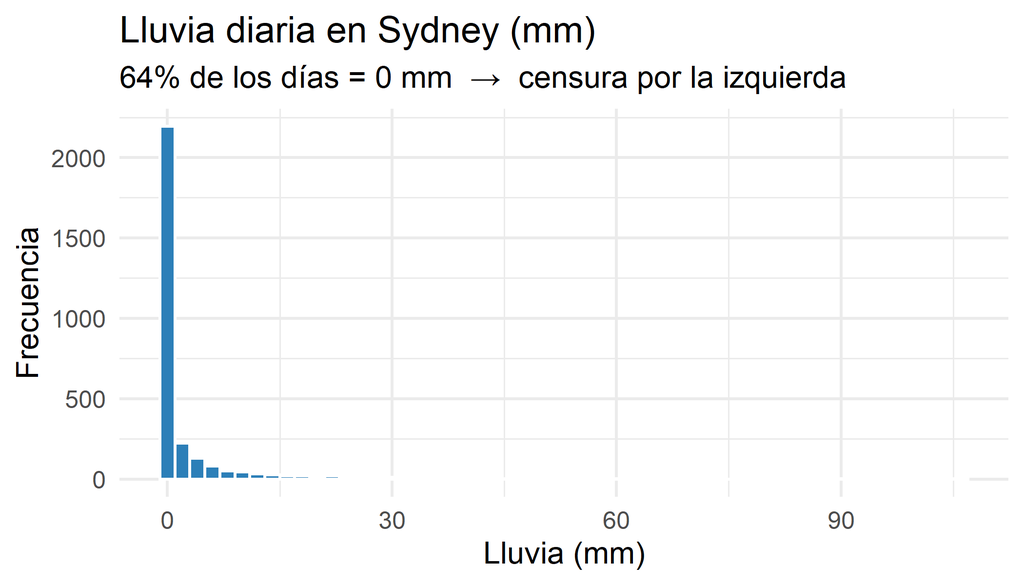

## OLS ingenuo vs Tobit

```r
ols_ll <- lm(f_ll, data = lluvia)                       # ignora la censura
tob_ll <- censReg(f_ll, left = 0, data = lluvia)        # Tobit (MLE)
sum(fitted(ols_ll) < 0)                                 # predicciones imposibles de OLS
```

```
[1] 504
```

```r
round(coef(summary(tob_ll)), 3)
```

```
             Estimate Std. error t value Pr(> t)
(Intercept)   202.211     64.119   3.154   0.002
temp_max       -0.723      0.087  -8.268   0.000
viento_max      0.188      0.028   6.753   0.000
humedad_pm      0.361      0.026  13.953   0.000
presion_pm     -0.223      0.062  -3.590   0.000
nubosidad_pm    0.816      0.175   4.657   0.000
logSigma        2.759      0.023 119.384   0.000
```

Todos los coeficientes son **significativos** y con **signo físico correcto**: humedad (+), nubosidad (+), viento (+), presión (−), temperatura (−).

## Efectos marginales y métricas de ajuste

```r
round(margEff(tob_ll), 4)        # efecto sobre E[lluvia OBSERVADA] (no sobre la latente)
```

```
    temp_max   viento_max   humedad_pm   presion_pm nubosidad_pm
     -0.2049       0.0532       0.1023      -0.0631       0.2312
```

| Métrica | Valor |
| --- | --- |
| McKelvey–Zavoina (latente) | 0.269 |
| McFadden | 0.059 |
| cor² (observada) | 0.158 |
| Pred. imposibles OLS | 504 |
| Pred. imposibles Tobit | 0 |

## Diagnóstico: ¿se cumplen los supuestos? **No.**

```r
# Normalidad (Jarque-Bera sobre residuos generalizados) y homocedasticidad (LR)
homo <- crch(f_ll, data = lluvia, left = 0, dist = "gaussian")
het  <- crch(lluvia_mm ~ temp_max+viento_max+humedad_pm+presion_pm+nubosidad_pm |
                         temp_max+viento_max+humedad_pm+presion_pm+nubosidad_pm,
             data = lluvia, left = 0, dist = "gaussian")
lrtest(homo, het)[2, c("Chisq", "Pr(>Chisq)")]          # H0: homocedasticidad
```

```
   Chisq Pr(>Chisq)
2 294.55  < 2.2e-16 ***
---
Signif. codes:  0 '***' 0.001 '**' 0.01 '*' 0.05 '.' 0.1 ' ' 1
```

**Normalidad:** Jarque-Bera p ≈ 0 (asimetría 2.2, curtosis 11.6) → **rechazada**. **Homocedasticidad:** LR p < 0.001 → **rechazada**. ⇒ El Tobit básico aquí es **inconsistente**: usar versión heterocedástica / robusta.

# 4B · Práctico B - Aptitud académica

## Un caso “de manual” (censura por la derecha)

```r
url <- "https://raw.githubusercontent.com/1mulerd/workshop4-tobit-mci002/main/data/apt.csv"
apt <- read.csv(url); apt$prog <- factor(apt$prog)
```

```r
f_ap <- apt ~ read + math + prog            # techo (censura derecha) en U = 800
c(observaciones = nrow(apt), en_el_techo = sum(apt$apt == 800))
```

```
observaciones   en_el_techo
          200            17
```

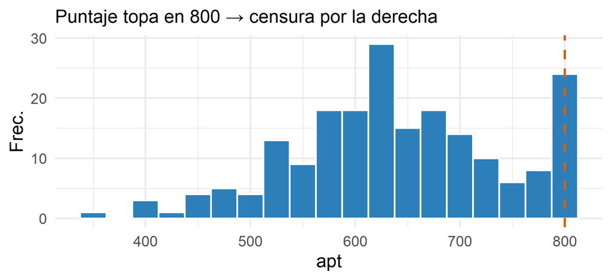

## Tobit: ajuste fuerte y coeficientes claros

```r
tob_ap <- censReg(f_ap, left = -Inf, right = 800, data = apt)
round(coef(summary(tob_ap)), 3)
```

```
               Estimate Std. error t value Pr(> t)
(Intercept)     209.566     32.772   6.395   0.000
read              2.698      0.619   4.360   0.000
math              5.914      0.710   8.332   0.000
proggeneral     -12.715     12.406  -1.025   0.305
progvocational  -46.144     13.724  -3.362   0.001
logSigma          4.185      0.053  78.946   0.000
```

| Métrica | Valor |
| --- | --- |
| McKelvey–Zavoina (latente) | 0.616 |
| McFadden | 0.083 |
| cor² (observada) | 0.611 |

`read` y `math` muy significativos; `math` pesa más. **McKelvey–Zavoina ≈ 0.62** → buen ajuste.

## Diagnóstico: aquí los supuestos **sí** se cumplen

```r
homo_a <- crch(f_ap, data = apt, left = -Inf, right = 800, dist = "gaussian")
het_a  <- crch(apt ~ read+math+prog | read+math+prog,
               data = apt, left = -Inf, right = 800, dist = "gaussian")
lrtest(homo_a, het_a)[2, c("Chisq", "Pr(>Chisq)")]      # H0: homocedasticidad
```

```
   Chisq Pr(>Chisq)
2 2.8527     0.5828
```

**Normalidad:** Jarque-Bera p = 0.53 → **no se rechaza**.

**Homocedasticidad:** LR p = 0.58 → **no se rechaza**. ✔ Tobit válido.

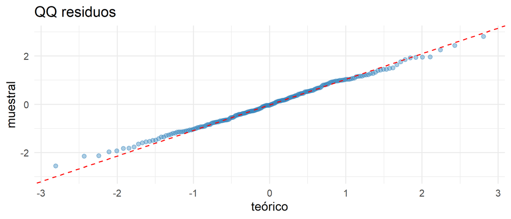

# 5 · Comparación y análisis crítico

## El mismo método, dos realidades

| Aspecto | A — Lluvia | B — Aptitud |
| --- | --- | --- |
| Dominio | Ingeniería (hidrología) | Educación |
| Censura | Izquierda (0); 64% | Derecha (800); 8.5% |
| McKelvey–Zavoina | 0.27 | 0.62 |
| cor² observada | 0.16 | 0.61 |
| Normalidad | Rechazada | OK |
| Homocedasticidad | Rechazada | OK |
| Tobit válido | Con reservas | Sí |

**¿Por qué difieren?** No es culpa del método. La **lluvia diaria** es un fenómeno de altísima varianza y nuestras covariables (de un mismo instante) capturan poco; además su asimetría rompe la normalidad. La **aptitud** se explica casi linealmente con `read`/`math`, con error bien comportado.

## Ventajas, limitaciones y extensiones

**Ventajas**

- Usa **toda** la muestra (no descarta los censurados).
- MLE eficiente bajo sus supuestos.
- Interpretable; no predice imposibles.

**Limitaciones**

- Supuestos **fuertes** (normalidad/homoced.).
- Un **único** proceso decide *participar* y *cuánto*.
- Sensible a especificación.

**Extensiones:** **Heckman** (selección: participar y nivel separados) · **doble valla de Cragg** · **Tobit heterocedástico** · errores robustos. **No** uses Tobit si el cero es una decisión distinta del monto.

## Conclusiones

1. **Tobit** modela variables **censuradas** vía una **latente** y MLE.
2. Se interpreta con **efectos marginales**, no con los β directos.
3. La calidad se juzga con **pseudo-R² (McKelvey–Zavoina)**, AIC/LR y, sobre todo, **diagnóstico de supuestos**.
4. Mismo método, dos resultados: **aptitud** (impecable) vs **lluvia** (modesto, supuestos violados) → criterio del analista.

**Referencias:** Tobin (1958); Amemiya (1984); Wooldridge, *Introductory Econometrics*, cap. 17; McKelvey & Zavoina (1975); UCLA OARC, *Tobit Models*.

[figure not shown]

**¡Gracias! ¿Preguntas?**